# Regression and model validation

*Describe the work this week and summarize your learning.*

- Describe your work and results clearly.
- Assume the reader has an introductory course level understanding of writing and reading R code as well as statistical methods.
- Assume the reader has no previous knowledge of your data or the more advanced methods you are using.

```r
date()
```

```
## [1] "Thu Nov 12 10:31:33 2020"
```

```r
ds <- read.csv("C:/Users/Heli/Heli/HY/Introduction to Open Data Science/Projects/IODS-project/data\\learning2014.csv", header=TRUE)
ds$Points
```

```
##   [1] 25 12 24 10 22 21 21 31 24 26 31 31 23 25 21 31 20 22  9 24 28 30 24  9 26
##  [26] 32 32 33 29 30 19 23 19 12 10 11 20 26 31 20 23 12 24 17 29 23 28 31 23 25
##  [51] 18 19 22 25 21  9 28 25 29 33 33 25 18 22 17 25 28 22 26 11 29 22 21 28 33
##  [76] 16 31 22 31 23 26 12 26 31 19 30 12 17 18 19 21 24 28 17 18 17 23 26 28 31
## [101] 27 25 23 21 27 28 23 21 25 11 19 24 28 21 24 24 20 19 30 22 16 16 19 30 23
## [126] 19 18 28 21 19 27 24 21 20 28 12 21 28 31 18 25 19 21 16  7 21 17 22 18 25
## [151] 24 23 23 26 12 32 22 20 21 23 20 28 31 18 30 19
```

```r
dim(ds)
```

```
## [1] 166   7
```

```r
str(ds)
```

```
## 'data.frame':    166 obs. of  7 variables:
##  $ gender  : chr  "F" "M" "F" "M" ...
##  $ Age     : int  53 55 49 53 49 38 50 37 37 42 ...
##  $ attitude: num  1.5 1.67 1.5 2.17 1.83 ...
##  $ deep    : num  3.58 2.92 3.5 3.5 3.67 ...
##  $ stra    : num  3.38 2.75 3.62 3.12 3.62 ...
##  $ surf    : num  2.58 3.17 2.25 2.25 2.83 ...
##  $ Points  : int  25 12 24 10 22 21 21 31 24 26 ...
```

```r
summary(ds)
```

```
##     gender               Age           attitude          deep
##  Length:166         Min.   :17.00   Min.   :1.000   Min.   :1.583
##  Class :character   1st Qu.:21.00   1st Qu.:1.500   1st Qu.:3.333
##  Mode  :character   Median :22.00   Median :1.667   Median :3.667
##                     Mean   :25.51   Mean   :1.883   Mean   :3.680
##                     3rd Qu.:27.00   3rd Qu.:2.000   3rd Qu.:4.083
##                     Max.   :55.00   Max.   :4.667   Max.   :4.917
##       stra            surf           Points
##  Min.   :1.250   Min.   :1.583   Min.   : 7.00
##  1st Qu.:2.625   1st Qu.:2.417   1st Qu.:19.00
##  Median :3.188   Median :2.833   Median :23.00
##  Mean   :3.121   Mean   :2.787   Mean   :22.72
##  3rd Qu.:3.625   3rd Qu.:3.167   3rd Qu.:27.75
##  Max.   :5.000   Max.   :4.333   Max.   :33.00
```

The dataset contains 166 rows and 7 columns. It includes the gender (F/M), the age, the points and some combination variables built using mean. These variables and the original variables they are combined are:

attitude: Aa, Ab, Ac, Ad, Ae, Af deep: D03+D11+D19+D27, D07+D14+D22+D30, D06+D15+D23+D31 surf: SU02+SU10+SU18+SU26, SU05+SU13+SU21+SU29, SU08+SU16+SU24+SU32 stra: ST01+ST09+ST17+ST25, ST04+ST12+ST20+ST28

Gender is of type chr, age and points are of type int and the rest of the variables are of type num as shown here: ‘data.frame’: 166 obs. of 7 variables: $ X.gender. : chr “"F"” “"M"” “"F"” “"M"” … $ X.Age. : int 53 55 49 53 49 38 50 37 37 42 … $ X.attitude.: num 1.5 1.67 1.5 2.17 1.83 … $ X.deep. : num 3.58 2.92 3.5 3.5 3.67 … $ X.stra. : num 3.38 2.75 3.62 3.12 3.62 … $ X.surf. : num 2.58 3.17 2.25 2.25 2.83 … $ X.Points. : int 25 12 24 10 22 21 21 31 24 26 …

The minimum age in the dataset is 17, maximum 55. Values for attitude are between 1.000-4.667, for deep between 1.583-4.917, stra 1.250-5.000, and surf 1.583-4.333. The minimum points are 7.00 and the maximum points are 33.00. The table below shows also the 1st quadrant, median, mean, and 3. quadrant for each variable.

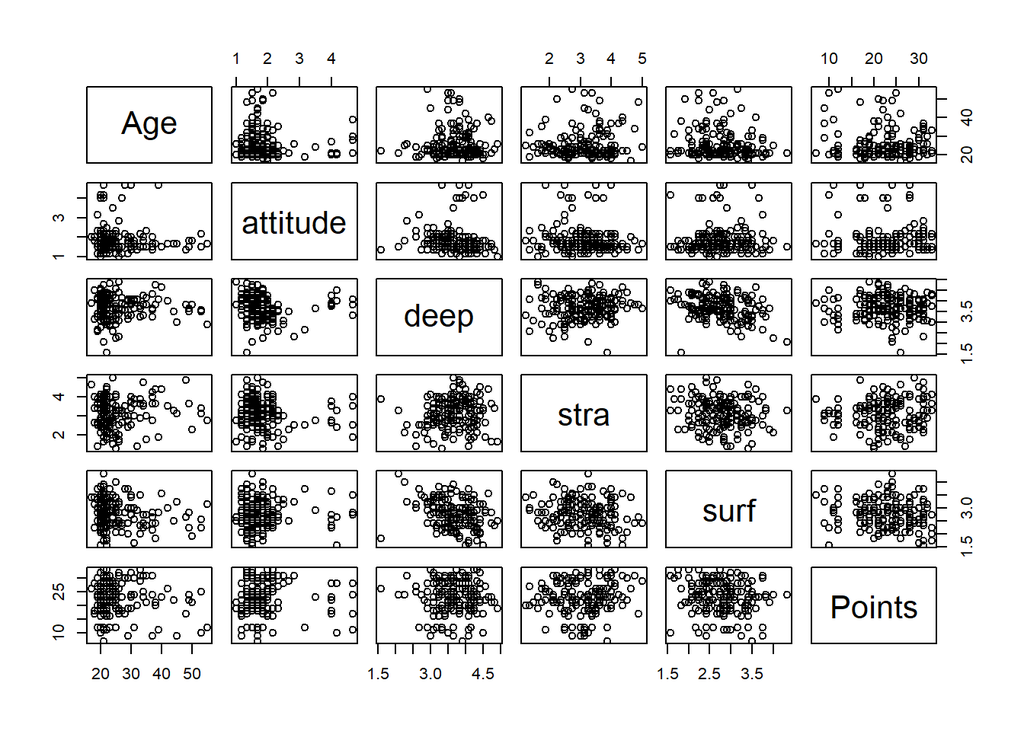

```r
pairs(ds[-1])
```

The scatter plot above describes the relationships between the variables. We have removed gender from the scatter plot.

```r
library(GGally)
```

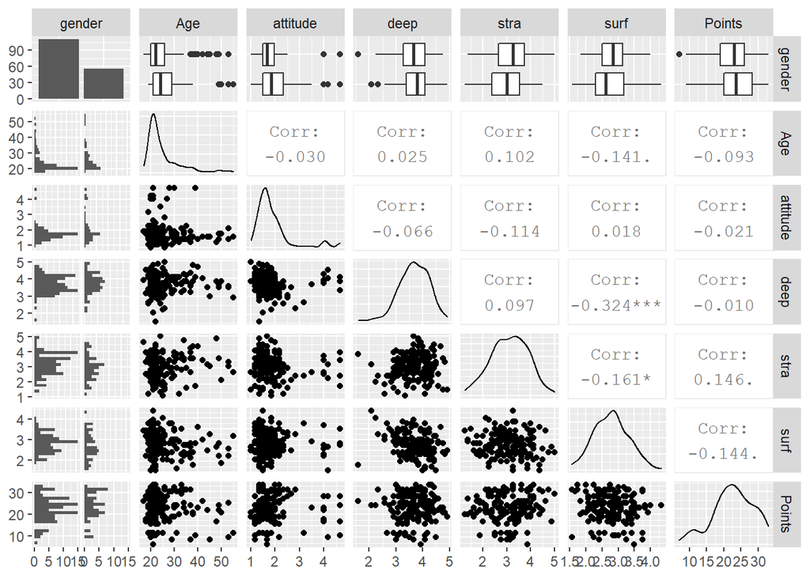

```r
library(ggplot2)
p <- ggpairs(ds, mapping = aes(), lower = list(combo = wrap("facethist", bins = 20)))
p
```

Above you can see a more advanced plot describing for instance the correlation of different variables to each others and the distribuiton of each variable.

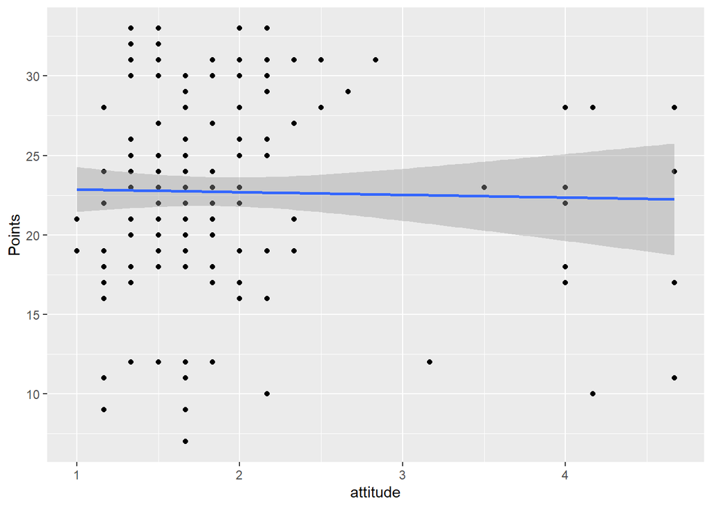

```r
# a scatter plot of points versus attitude
library(ggplot2)
# colnames(learning2014)[7] <- "points"

qplot(attitude, Points, data = ds) + geom_smooth(method = "lm")
```

```r
my_model <- lm(Points  ~ attitude + deep + Age, data = ds )
summary(my_model)
```

```
##
## Call:
## lm(formula = Points ~ attitude + deep + Age, data = ds)
##
## Residuals:
##      Min       1Q   Median       3Q      Max
## -16.0562  -3.7634   0.2952   4.6517  10.7479
##
## Coefficients:
##             Estimate Std. Error t value Pr(>|t|)
## (Intercept) 25.26830    3.69183   6.844  1.5e-10 ***
## attitude    -0.19559    0.61906  -0.316    0.752
## deep        -0.10027    0.83390  -0.120    0.904
## Age         -0.07111    0.05940  -1.197    0.233
## ---
## Signif. codes:  0 '***' 0.001 '**' 0.01 '*' 0.05 '.' 0.1 ' ' 1
##
## Residual standard error: 5.921 on 162 degrees of freedom
## Multiple R-squared:  0.009356,   Adjusted R-squared:  -0.008989
## F-statistic:  0.51 on 3 and 162 DF,  p-value: 0.6759
```

Residuals explain the minimum and maximum values that are -16.0562 and 10.7479. It also shows that the median is 0.2952, the first quatrain is -3.7634 and the third is 4.6517. The t-value measures the size of the difference relative to the variation, so the bigger the number the greater the evidence against the null hypothesis. Age seems to have the biggest difference (-1.197) but still not big enough to refute the 0-hypotheses. The t-value cannot refute null hypotheses, not statistically significant. p-value (Pr) is smallest with Age (0.233) but still bigger than 0.05 so none of these are statistically significant. Based on the results, null hypotheses cannot be refute. Residual standard error is 5.921. R-squared values indicate explain how well the variance is explained by the model. Multiple R-squared (0.009356) and Adjusted R-squared (-0.008989) are almost the same and explaind the variant very poorely.

```r
my_model <- lm(Points  ~ stra + surf +gender, data = ds )
summary(my_model)
```

```
##
## Call:
## lm(formula = Points ~ stra + surf + gender, data = ds)
##
## Residuals:
##      Min       1Q   Median       3Q      Max
## -15.2430  -3.4525   0.3105   4.2753  10.2382
##
## Coefficients:
##             Estimate Std. Error t value Pr(>|t|)
## (Intercept)  22.2924     3.4464   6.468 1.12e-09 ***
## stra          1.0936     0.6022   1.816   0.0712 .
## surf         -1.2249     0.8752  -1.400   0.1635
## genderM       1.2599     0.9736   1.294   0.1974
## ---
## Signif. codes:  0 '***' 0.001 '**' 0.01 '*' 0.05 '.' 0.1 ' ' 1
##
## Residual standard error: 5.81 on 162 degrees of freedom
## Multiple R-squared:  0.0462, Adjusted R-squared:  0.02854
## F-statistic: 2.616 on 3 and 162 DF,  p-value: 0.05295
```

```r
confint(my_model)
```

```
##                   2.5 %    97.5 %
## (Intercept) 15.48661602 29.098118
## stra        -0.09564338  2.282801
## surf        -2.95303542  0.503321
## genderM     -0.66254961  3.182448
```

```r
my_model <- lm(Points  ~ attitude, data = ds )
summary(my_model)
```

```
##
## Call:
## lm(formula = Points ~ attitude, data = ds)
##
## Residuals:
##      Min       1Q   Median       3Q      Max
## -15.7533  -3.7392   0.2186   4.9615  10.3311
##
## Coefficients:
##             Estimate Std. Error t value Pr(>|t|)
## (Intercept)  23.0346     1.2479  18.459   <2e-16 ***
## attitude     -0.1688     0.6165  -0.274    0.785
## ---
## Signif. codes:  0 '***' 0.001 '**' 0.01 '*' 0.05 '.' 0.1 ' ' 1
##
## Residual standard error: 5.911 on 164 degrees of freedom
## Multiple R-squared:  0.0004569,  Adjusted R-squared:  -0.005638
## F-statistic: 0.07496 on 1 and 164 DF,  p-value: 0.7846
```

NOt significant

```r
my_model <- lm(Points  ~ deep, data = ds )
summary(my_model)
```

```
##
## Call:
## lm(formula = Points ~ deep, data = ds)
##
## Residuals:
##      Min       1Q   Median       3Q      Max
## -15.6913  -3.6935   0.2862   4.9957  10.3537
##
## Coefficients:
##             Estimate Std. Error t value Pr(>|t|)
## (Intercept)  23.1141     3.0908   7.478 4.31e-12 ***
## deep         -0.1080     0.8306  -0.130    0.897
## ---
## Signif. codes:  0 '***' 0.001 '**' 0.01 '*' 0.05 '.' 0.1 ' ' 1
##
## Residual standard error: 5.913 on 164 degrees of freedom
## Multiple R-squared:  0.000103,   Adjusted R-squared:  -0.005994
## F-statistic: 0.01689 on 1 and 164 DF,  p-value: 0.8967
```

Not significant

```r
my_model <- lm(Points  ~ Age, data = ds )
summary(my_model)
```

```
##
## Call:
## lm(formula = Points ~ Age, data = ds)
##
## Residuals:
##      Min       1Q   Median       3Q      Max
## -16.0360  -3.7531   0.0958   4.6762  10.8128
##
## Coefficients:
##             Estimate Std. Error t value Pr(>|t|)
## (Intercept) 24.52150    1.57339  15.585   <2e-16 ***
## Age         -0.07074    0.05901  -1.199    0.232
## ---
## Signif. codes:  0 '***' 0.001 '**' 0.01 '*' 0.05 '.' 0.1 ' ' 1
##
## Residual standard error: 5.887 on 164 degrees of freedom
## Multiple R-squared:  0.008684,   Adjusted R-squared:  0.00264
## F-statistic: 1.437 on 1 and 164 DF,  p-value: 0.2324
```

Not significant

```r
my_model <- lm(Points  ~ stra, data = ds )
summary(my_model)
```

```
##
## Call:
## lm(formula = Points ~ stra, data = ds)
##
## Residuals:
##      Min       1Q   Median       3Q      Max
## -16.5581  -3.8198   0.1042   4.3024  10.1394
##
## Coefficients:
##             Estimate Std. Error t value Pr(>|t|)
## (Intercept)   19.233      1.897  10.141   <2e-16 ***
## stra           1.116      0.590   1.892   0.0603 .
## ---
## Signif. codes:  0 '***' 0.001 '**' 0.01 '*' 0.05 '.' 0.1 ' ' 1
##
## Residual standard error: 5.849 on 164 degrees of freedom
## Multiple R-squared:  0.02135,    Adjusted R-squared:  0.01538
## F-statistic: 3.578 on 1 and 164 DF,  p-value: 0.06031
```

Not significant

```r
my_model <- lm(Points  ~ surf, data = ds )
summary(my_model)
```

```
##
## Call:
## lm(formula = Points ~ surf, data = ds)
##
## Residuals:
##      Min       1Q   Median       3Q      Max
## -14.6539  -3.3744   0.3574   4.4734  10.2234
##
## Coefficients:
##             Estimate Std. Error t value Pr(>|t|)
## (Intercept)  27.2017     2.4432  11.134   <2e-16 ***
## surf         -1.6091     0.8613  -1.868   0.0635 .
## ---
## Signif. codes:  0 '***' 0.001 '**' 0.01 '*' 0.05 '.' 0.1 ' ' 1
##
## Residual standard error: 5.851 on 164 degrees of freedom
## Multiple R-squared:  0.02084,    Adjusted R-squared:  0.01487
## F-statistic:  3.49 on 1 and 164 DF,  p-value: 0.06351
```

Not significant

```r
my_model <- lm(Points  ~ gender, data = ds )
summary(my_model)
```

```
##
## Call:
## lm(formula = Points ~ gender, data = ds)
##
## Residuals:
##      Min       1Q   Median       3Q      Max
## -15.3273  -3.3273   0.5179   4.5179  10.6727
##
## Coefficients:
##             Estimate Std. Error t value Pr(>|t|)
## (Intercept)  22.3273     0.5613  39.776   <2e-16 ***
## genderM       1.1549     0.9664   1.195    0.234
## ---
## Signif. codes:  0 '***' 0.001 '**' 0.01 '*' 0.05 '.' 0.1 ' ' 1
##
## Residual standard error: 5.887 on 164 degrees of freedom
## Multiple R-squared:  0.008632,   Adjusted R-squared:  0.002587
## F-statistic: 1.428 on 1 and 164 DF,  p-value: 0.2338
```

Not significant. We choose stra for further investigation. (biggest t-value)

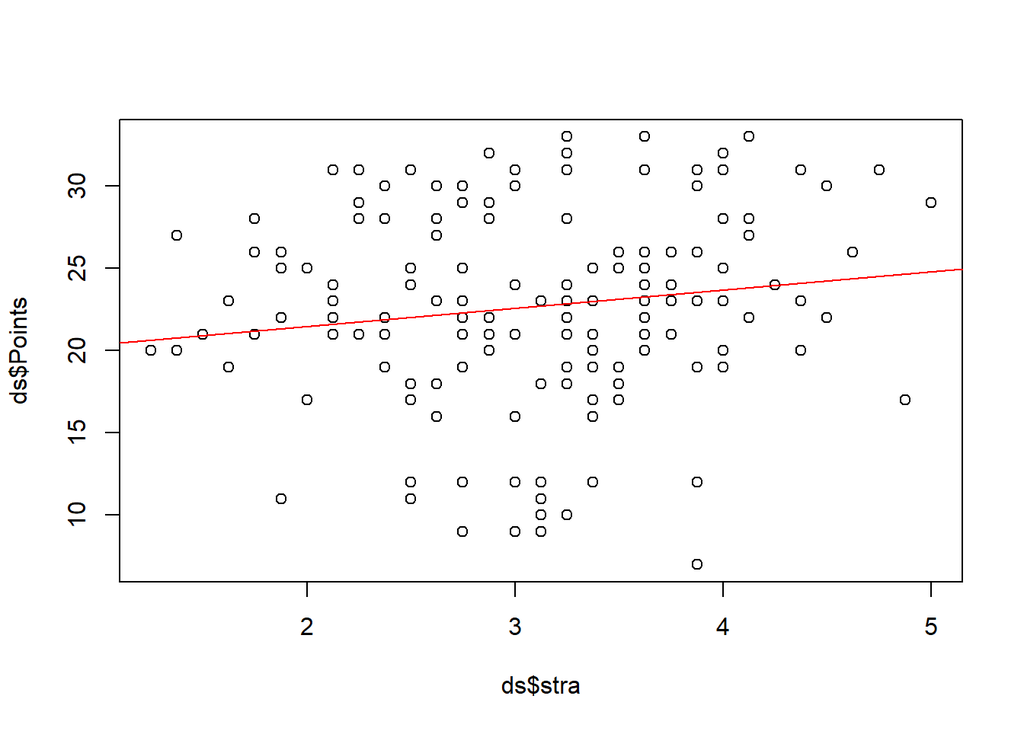

```r
my_model <- lm(Points  ~ stra, data = ds )
plot(ds$stra,ds$Points)
abline(my_model, col="red")
```

```r
my_model
```

```
##
## Call:
## lm(formula = Points ~ stra, data = ds)
##
## Coefficients:
## (Intercept)         stra
##      19.234        1.116
```

```r
summary(my_model)
```

```
##
## Call:
## lm(formula = Points ~ stra, data = ds)
##
## Residuals:
##      Min       1Q   Median       3Q      Max
## -16.5581  -3.8198   0.1042   4.3024  10.1394
##
## Coefficients:
##             Estimate Std. Error t value Pr(>|t|)
## (Intercept)   19.233      1.897  10.141   <2e-16 ***
## stra           1.116      0.590   1.892   0.0603 .
## ---
## Signif. codes:  0 '***' 0.001 '**' 0.01 '*' 0.05 '.' 0.1 ' ' 1
##
## Residual standard error: 5.849 on 164 degrees of freedom
## Multiple R-squared:  0.02135,    Adjusted R-squared:  0.01538
## F-statistic: 3.578 on 1 and 164 DF,  p-value: 0.06031
```

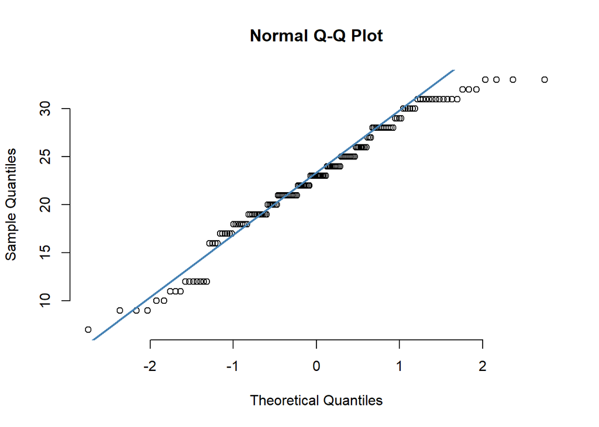

```r
qqnorm(ds$Points, pch = 1, frame = FALSE)
qqline(ds$Points, col = "steelblue", lwd = 2)
```

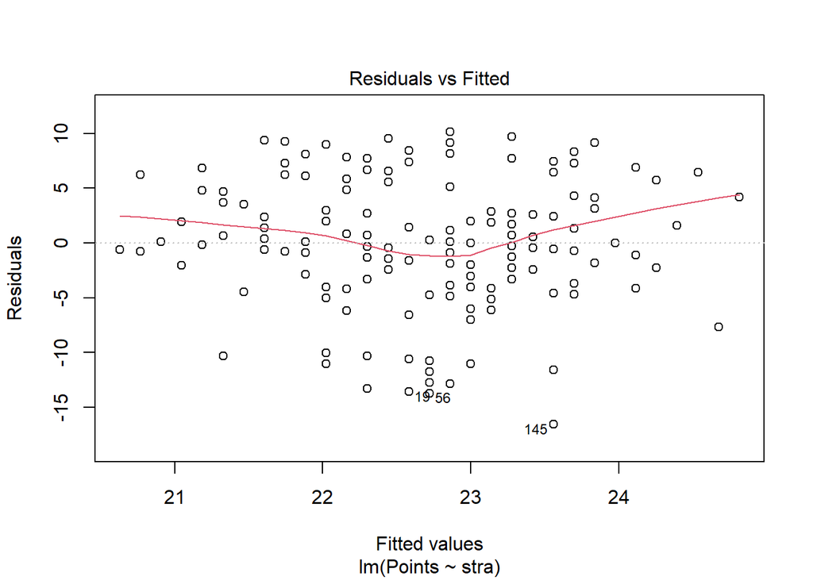

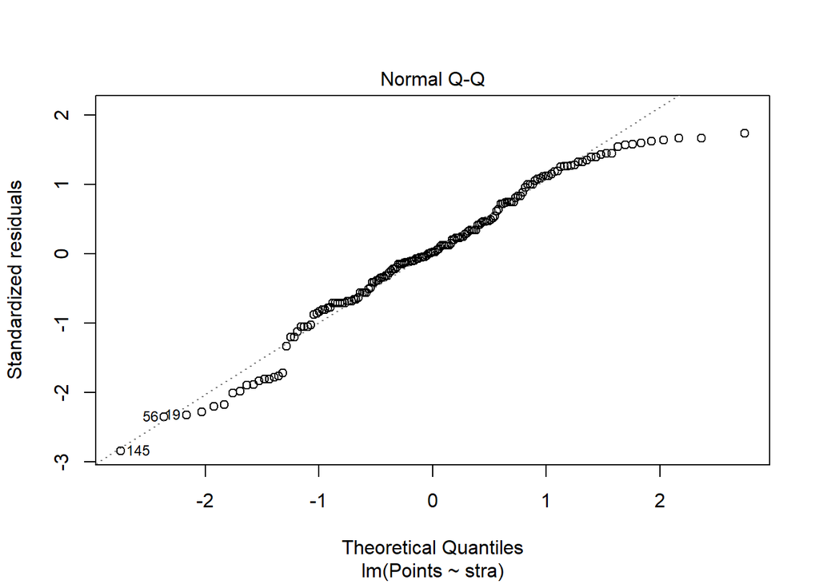

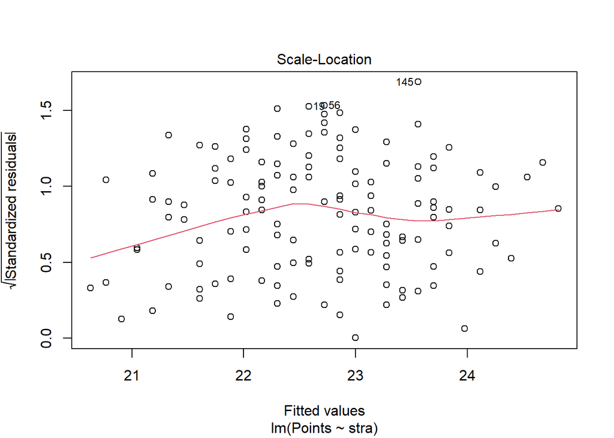

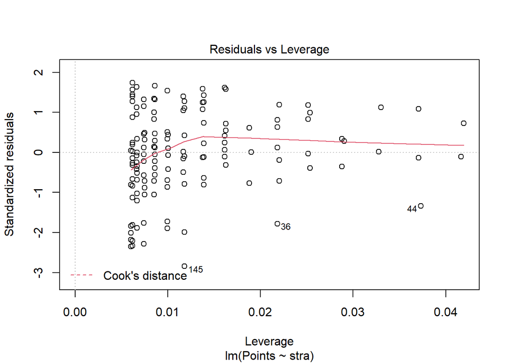

```r
plot(lm(Points~stra,data=ds))
```

The assumption is that the strategic approach (stra) defines the overall points (Points): Points is modelled as a linear combination of stra. Residual is the difference between an observed value of the response variable and the fitted value, the error. Residuals can be used to define the validity of the model assumptions. There are several assumptions for the errors. First of them is that they are normally distributed. QQ-plot of the residuals is a method to explore the assumption that the errors of the model are normally distributed. The better the data points aline with the line the better they are normally distributed. In our example QQ-plot the beginning and end of the line do not follow but in the middle the data point are quite well following the line. We could say the errors are well fitting the line with values -1 and 1.5, reasonably well with values less than -1, not so well fitting with values larger than 1.5. Therefore the errors are reasonable well normally distributed. The second assumption is the constant variance of errors, the size of the errors is not dependent on the explanatory variables. This can be explored with a scatter plot of residuals versus model predictions. Any patter in the scatter plot implies that there is a problem with this assumption. In our example there is no patter to be found and therefore this assumption is correct. Leverage is used to measure how much impact an observation has to the model. Residuals vs leverage plot can be used to find observations that have unusually high impact, the outliers. In our example there are no outliers.